# Indel Signature InsDel2a

# InsDel2a

(corresponds to 83-type signature C_ID2)

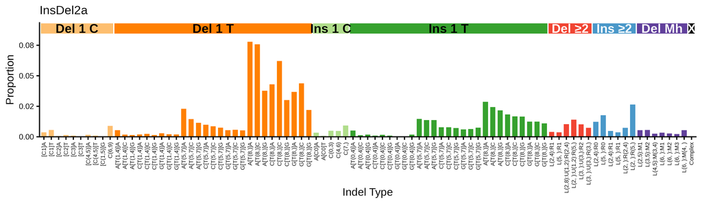

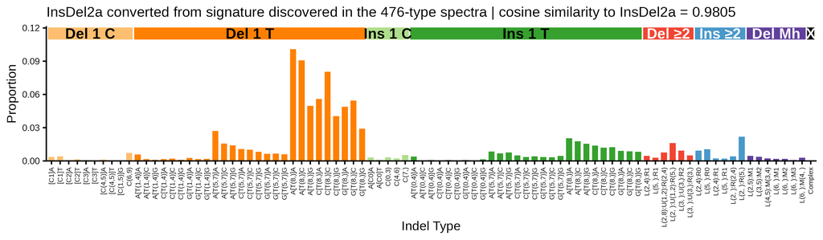

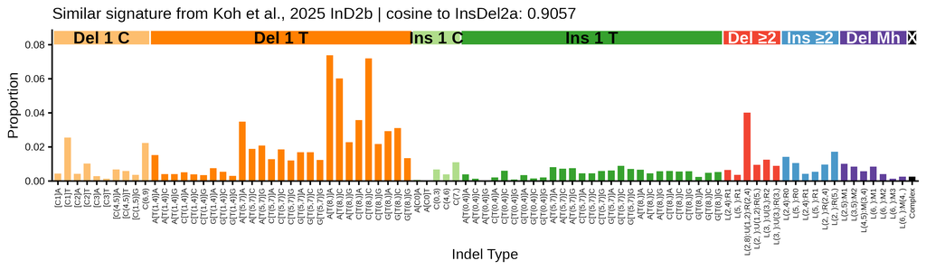

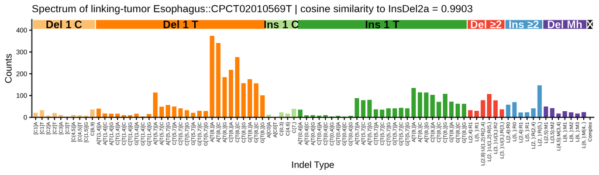

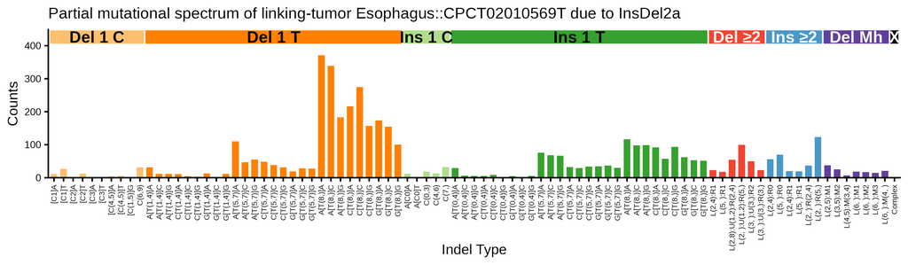

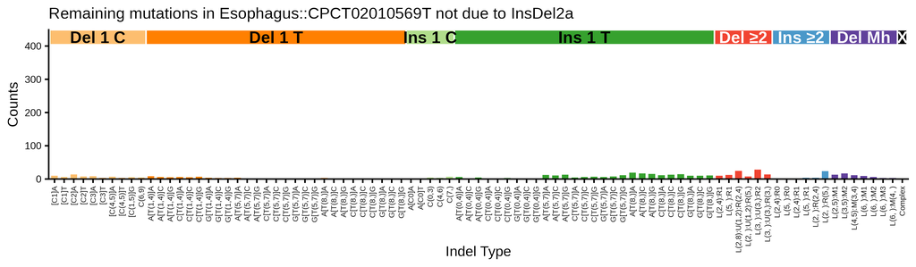

## 476-type representations corresponding to InsDel2a

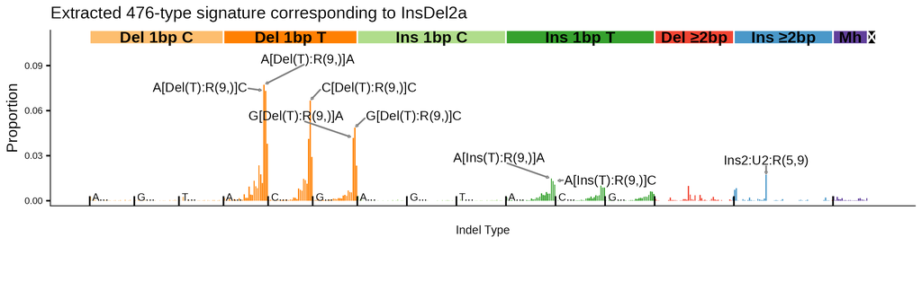

476-type spectrum of the linking tumor Esophagus::CPCT02010569T; cosine similarity to the extracted 476-type signature is 0.9679

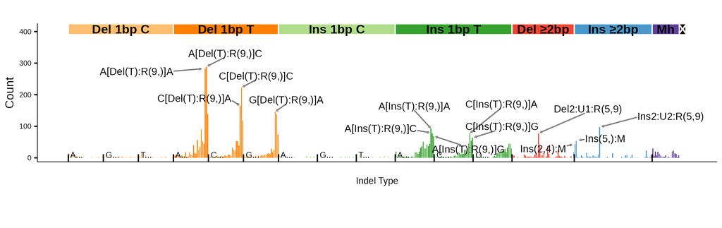

## 83-type signature corresponding to InsDel2a (C_ID2)

**Note**

InsDel2a and 2c 89-type and 476-type extractions collapse to 83-type signature close to C_ID2. InsDel2b extractions have more insertions of a single T in long poly-T contexts, which is absent in C_ID2, as well as some single T deletions in stretches of 4 and 5 T’s, which are also absent C_ID2

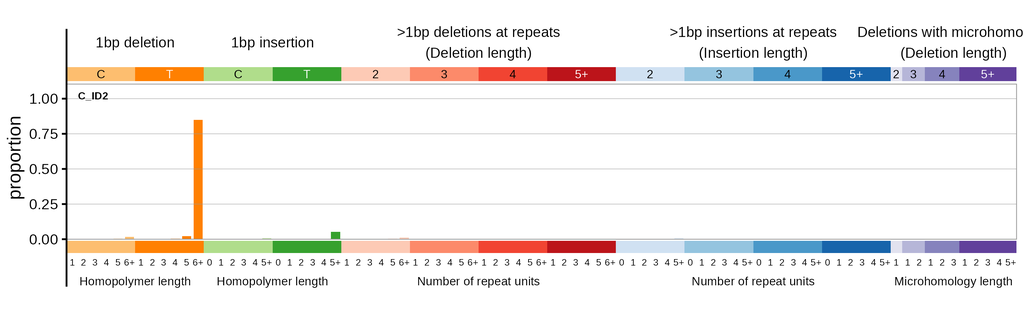

**Click here to see with insertions and deletions of T in long poly-T suppressed**

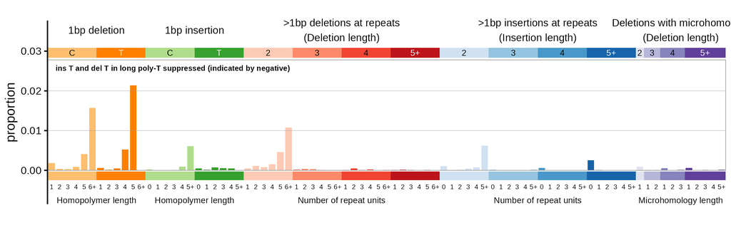

83-type signature converted from signature discovered in the 476-type spectra | cosine similarity to C_ID2: 0.981

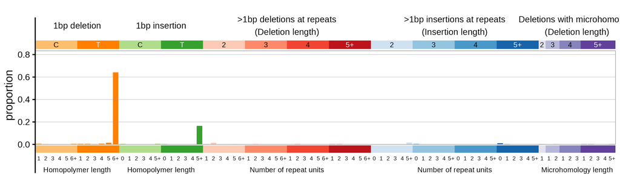

**Click here to see with insertions and deletions of T in long poly-T suppressed**

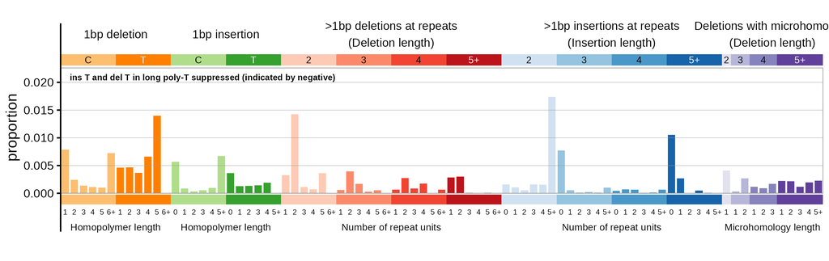

83-type spectrum of the linking tumor Esophagus::CPCT02010569T | cosine similarly to C_ID2: 0.8961

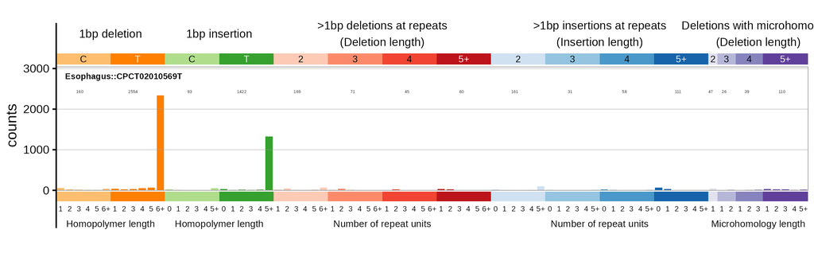

**Click here to see with insertions and deletions of T in long poly-T suppressed**

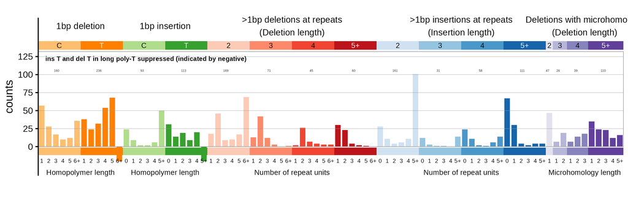

### Similar COSMIC signatures

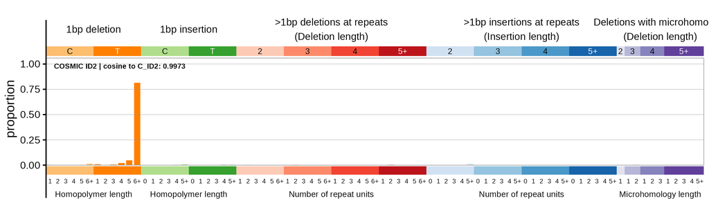

**Click here to see with insertions and deletions of T in long poly-T suppressed**

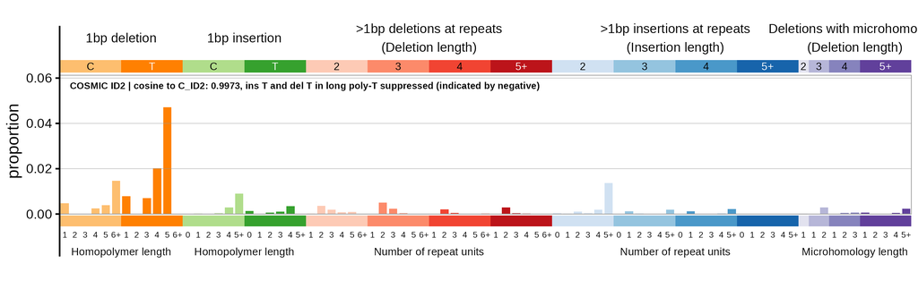

### Similar signatures from Jin et al. 2024

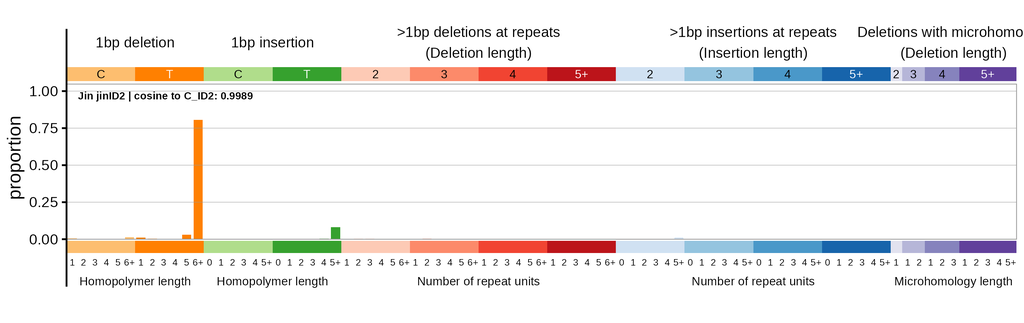

**Click here to see with insertions and deletions of T in long poly-T suppressed**

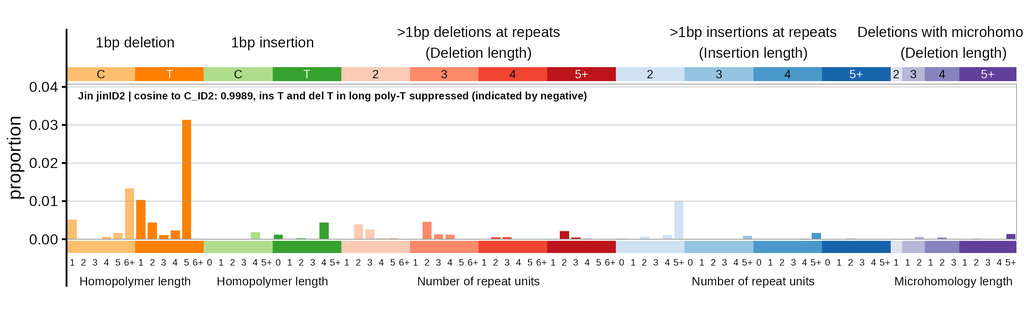